**Loading and Summarizing RGR Data in Python**

**Laura Stevens, Remy Poudel, Pratheek Mallya**

**May 2021**

# Introduction and Software

This notebook walks through the loading and generating visualizations of summary statistics of CSV (Comma Separated Values) files in a Python 3 work environment using the Pandas library. The Tables and Summary statistics section provides a brief introduction for how to calculate the frequencies and distribution statistics for categorical and continuous variables.

### Software and Packages

This tutorial is completed in Python. All packages used in this notebook are included by default in the workspace. However, we also have an example of a package installation using the notebook.

Packages used in this tutorial as well as additional packages that are useful for data manipulation and analysis are listed in the References Section.

### Package Installation

For installing a package, we use the pip command through the bash shell. We'll install the seaborn library, which is used for generating data visualizations, using the guide found [here](https://seaborn.pydata.org/installing.html). Packages need only be installed once, after which the code cell can be skipped or commented out (by using '#').

```python
%%bash
sudo python3 -m pip install seaborn
```

```
WARNING: Running pip as root will break packages and permissions. You should install packages reliably by using venv: https://pip.pypa.io/warnings/venv
```

### Importing Packages

For use in the notebook, installed packages need to be imported in the following way.

```python
import pandas as pd
import seaborn as sns
```

# Load and View Data

The root directory path in the workspace is `/mnt/workspace`, which is the home directory for the files in Jupyter, as well as the default working directory. The data and the documentation for a specific version (ordered by month) can be found in the following workspace folders:

- **Data**: `/mnt/workspace/Research Goes Red/<version>/Data`
- **Documentation**: `/mnt/workspace/Research Goes Red/<version>/Documentation`

For example, here are the data and documentation folders for the 03-2021 version of the RGR data:

- **Data**: `/mnt/workspace/Research Goes Red/v0_03-2021/Data`
- **Documentation**: `/mnt/workspace/Research Goes Red/v0_03-2021/Documentation`

### Loading the data

For loading csv files, we use the `read_csv` method in pandas, whose documentation can be found [here](https://pandas.pydata.org/docs/reference/api/pandas.read_csv.html). For our tutotial, let us load the RGR survey data from 03-2021:

```python
data = pd.read_csv('/mnt/workspace/Research Goes Red/v0_03-2021/Data/Survey/v0_03_2021_RGR_SURVEY_RGR.csv')
```

### Viewing the data

The following commands are helpful when viewing large datasets:

- `head()` This shows the first five rows of the data. By specifying a number in the parenthesis, you can control the number of rows displayed.
- `value_counts()` This gives the number of counts of unique values for a particular field (column) in the data. The typical usage is `<dataframe>.<field>.value_counts()`.
- `dtype()`: This gives an overview of the data type for the variable (or field names) in the dataset.

**Note:** Most commands that can be used on the entire dataset may lead to a large number of values printed in the output. Jupyter limits the number by default, but this can be controlled using the `pd.set_option()` method. The documentation can be found [here](https://pandas.pydata.org/docs/reference/api/pandas.set_option.html). Some examples:

- `pd.set_option('display.max_rows', None)`
- `pd.set_option('display.max_colwidth', 500)`

```python
data.head()
```

|  | Unnamed: 0 | subjid | rgr_topic1 | rgr_topic2 | rgr_topic3 | rgr_topic4 | rgr_topic5 | knows_cholesterol_levels_yn | tc | hdl | ... | hemorrhagic_stroke | prior_revasc | significant_blockage | none_of_these_conditions | no_diabetes | type1_diabetes | type2_diabetes | gestational_diabetes | wt_in_lbs | ht_in_inches |
| --- | --- | --- | --- | --- | --- | --- | --- | --- | --- | --- | --- | --- | --- | --- | --- | --- | --- | --- | --- | --- | --- |
| 0 | 0 | 7594007411 | Anxiety and/or stress | Weight | Mental health and/or depression | Health of family members | Sleep, including poor or inadequate sleep and ... | Yes | 105.0 | 95.0 | ... | No | No | No | Yes | Yes | No | No | No | 180.0 | 70.0 |
| 1 | 1 | 8895109730 | Exercise | Weight | Financial well-being | Food, healthy eating, and/or availability of h... | Menopause and/or the years before and after me... | No | NaN | NaN | ... | No | No | No | Yes | Yes | No | No | No | 200.0 | 62.0 |
| 2 | 2 | 2766202432 | Access to care, paying for healthcare, and/or ... | Weight | Pain | Exercise | Sex | No | NaN | NaN | ... | No | No | No | Yes | No | No | No | Yes | 235.0 | 66.0 |
| 3 | 3 | 4901633067 | High blood pressure | Cholesterol | Food, healthy eating, and/or availability of h... | Weight | Sleep, including poor or inadequate sleep and ... | No | NaN | NaN | ... | No | No | No | Yes | Yes | No | No | No | 150.0 | 60.0 |
| 4 | 4 | 1901098431 | High blood pressure | Cholesterol | Menopause and/or the years before and after me... | Health of family members | Cancer | Yes | 199.0 | 67.0 | ... | No | No | No | Yes | Yes | No | No | No | 165.0 | 60.0 |

5 rows × 27 columns

```python
# Display the data type of each column
df_data_types = pd.DataFrame(data.dtypes, columns={'Data Type'})
df_data_types
```

|  | Data Type |
| --- | --- |
| Unnamed: 0 | int64 |
| subjid | int64 |
| rgr_topic1 | object |
| rgr_topic2 | object |
| rgr_topic3 | object |
| rgr_topic4 | object |
| rgr_topic5 | object |
| knows_cholesterol_levels_yn | object |
| tc | float64 |
| hdl | float64 |
| knows_blood_pressure_yn | object |
| sbp | float64 |
| dbp | float64 |
| hypertension | object |
| medication_for_hypertension | object |
| heart_attack | object |
| stroke | object |
| hemorrhagic_stroke | object |
| prior_revasc | object |
| significant_blockage | object |
| none_of_these_conditions | object |
| no_diabetes | object |
| type1_diabetes | object |
| type2_diabetes | object |
| gestational_diabetes | object |
| wt_in_lbs | float64 |
| ht_in_inches | float64 |

# Tables and Summary Statistics

### Tables and Frequencies

Getting the counts of one or multiple variables is easy in Python with the `value_counts()` function. The `value_counts()` function will create a set of counts. This function can be used to get counts of categorical variables in the data, as shown in the code below, which makes a table of the number of entries by `rgr_topic2` variable. The `dropna` parameter can be used to include or exclude `null` values by setting to `True` or `False`.

```python
# Display the counts of unique values of the rgr_topic2 column
df_count = pd.DataFrame(data.rgr_topic2.value_counts(dropna=False))
df_count
```

|  | rgr_topic2 |
| --- | --- |
| Food, healthy eating, and/or availability of healthy food | 421 |
| Weight | 400 |
| Memory, brain function, and/or healthy aging | 368 |
| Anxiety and/or stress | 365 |
| Health of family members | 294 |
| Access to care, paying for healthcare, and/or medications | 263 |
| Sleep, including poor or inadequate sleep and the impact that your sleeping patterns have on the rest of your life | 210 |
| Financial well-being | 205 |
| Mental health and/or depression | 204 |
| Exercise | 203 |
| High blood pressure | 168 |
| Menopause and/or the years before and after menopause | 162 |
| Cancer | 125 |
| Pain | 114 |
| Cholesterol | 109 |
| Caretaking | 34 |
| Sex | 24 |
| Social connection | 22 |
| Pregnancy related issues | 21 |
| Frailty | 10 |
| Neighborhood safety | 5 |

### Summary Statistics

The `describe()` command can be used to view distribution statistics for all variables in the data by calling `<data frame>.describe()` or for a single variable, by calling `<data frame>.<variable name>.describe()`. This summary command will display frequencies, mean, median, min, max for all the variables except for the category variables.

**NOTE:** `describe()` can be used on the entire dataset. Given the large size of the data, the command is called on a single variable below to limit the output displayed.

```python
# Display summary statistics for the 'hdl' variable
data.hdl.describe()
```

```
count    927.000000
mean      57.969364
std       20.415052
min        0.000000
25%       46.000000
50%       58.000000
75%       70.000000
max      100.000000
Name: hdl, dtype: float64
```

# Visualizations

We can generate visualizations such as graphs, plots, heatmaps, etc. easily using various python libraries. In this tutorial, we'll use the `seaborn` library to generate a simple histogram plot. The seaborn documentation and tutorials give detailed descriptions and examples for generating different types of visualizations, and can be found [here](https://seaborn.pydata.org/tutorial.html).

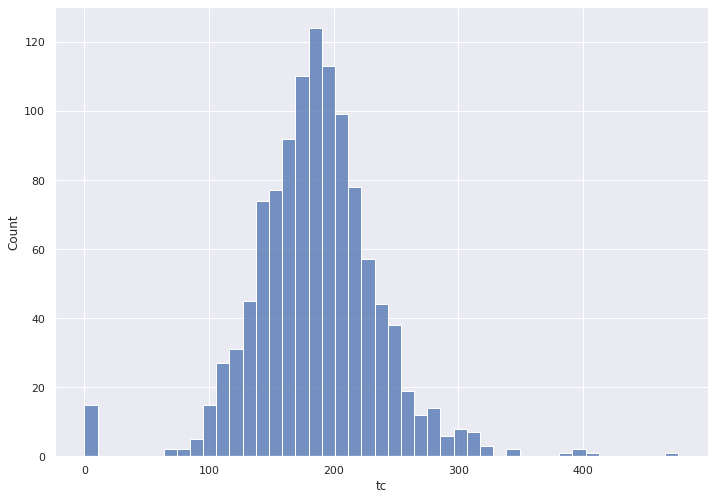

```python
# Generate a histogram plot of the 'tc' variable
sns.set(rc={'figure.figsize':(11.7,8.27)})
sns.histplot(data=data, x='tc')
```

# Need Help?

### Internet access in a PMP workspace

- Google and other useful programming sites including git and stack overflow are available in the workspace. Simply add a tab on by clicking the + on the blue, browser bar above.

### Billing, Data, or Analysis Questions?

- If you have questions about your account, billing, the GWTG data, or would like to request analysis help from the AHA Data Science Team, please file a ticket with the data team by selecting [Contact Us](https://precision.heart.org/contact) on the PMP portal under the About tab.

### Technical Questions or Issues?

- If you are having technical trouble installing software or packages, using the workspace or software in the workspace, please file a ticket with support by selecting [technical support](https://precision.heart.org/technical-support) on the PMP portal under the About tab.

# References

### Helpful Python Packages

- Data Manipulation
  - [pandas](https://pandas.pydata.org/)
- Tables and Display
  - [pandas-styling](https://pandas.pydata.org/docs/user_guide/style.html)
- Plotting and Graphs
  - [matplotlib](https://matplotlib.org/)
  - [plotly](https://plotly.com/python/)
  - [seaborn](https://seaborn.pydata.org/)

### Python Tutorials

- [Data Science With Python](https://realpython.com/tutorials/data-science/)
- [Python Documentation](https://docs.python.org/3/tutorial/index.html)

### Academic Publications and Guidelines

- [Descriptives Explanation](https://www.socialresearchmethods.net/kb/statdesc.php)
- [Reporting Descriptives in Clinical Studies](https://trialsjournal.biomedcentral.com/articles/10.1186/s13063-016-1189-4)

Use of the AHA Get With The Guidelines ® Datasets in the Precision Medicine Platform is a strategic initiative of the American Heart Association's Institute for Precision Cardiovascular Medicine. The Platform is supported by Hitachi Vantara and powered by Amazon Web Services.

[figure not shown]